# Urban Coyotes in California: An Exploratory Analysis of GBIF Occurrence Data

Author

Ben Irish

Published

September 25, 2026

# Introduction

*Canis latrans*, more commonly known as coyotes, are among the most adaptable carnivores in North America. Once confined largely to open plains and deserts, they have expanded across nearly the entire continent over the last century (Hody and Kays 2018) and are now a familiar presence in major cities (Gehrt et al. 2009). This report explores coyote occurrence records from California, drawn from the Global Biodiversity Information Facility (GBIF.org 2026). The central question is descriptive: where and when are coyotes observed, and how do observations differ between urban and non-urban areas? In the process, the analysis runs into a recurring theme in biodiversity data: records reflect not only where animals are, but where and when people are looking for them. The analysis is exploratory. Rather than testing a hypothesis, it characterizes the geographic, temporal, and seasonal patterns in the data. All analysis was performed in R (R Core Team 2025) using the rgbif (Chamberlain et al. 2025) and sf (Pebesma 2025) packages.

Table 1: Variables in the cleaned coyote occurrence dataset.

| Variable | Type | Description |
| --- | --- | --- |
| gbif_id | integer | Unique GBIF record identifier |
| lat, lon | numeric | Decimal latitude and longitude of the observation |
| coord_uncert_m | numeric | Coordinate uncertainty in meters |
| event_date | date | Date of the observation |
| year, month, day | integer | Components of the observation date |
| basis | character | Record type (e.g. human observation, specimen) |
| institution | character | Institution that supplied the record |
| recorded_by | character | Observer name(s) |
| urban | character | Whether the point falls in a Census urban area |

The cleaned dataset contains 24,371 georeferenced coyote observations from California spanning 1886 to 2026, each tagged as urban or non-urban based on whether it falls within a Census-defined urban area. Table 1 describes the variables retained for analysis.

# Exploratory Analysis

## Geographic distribution

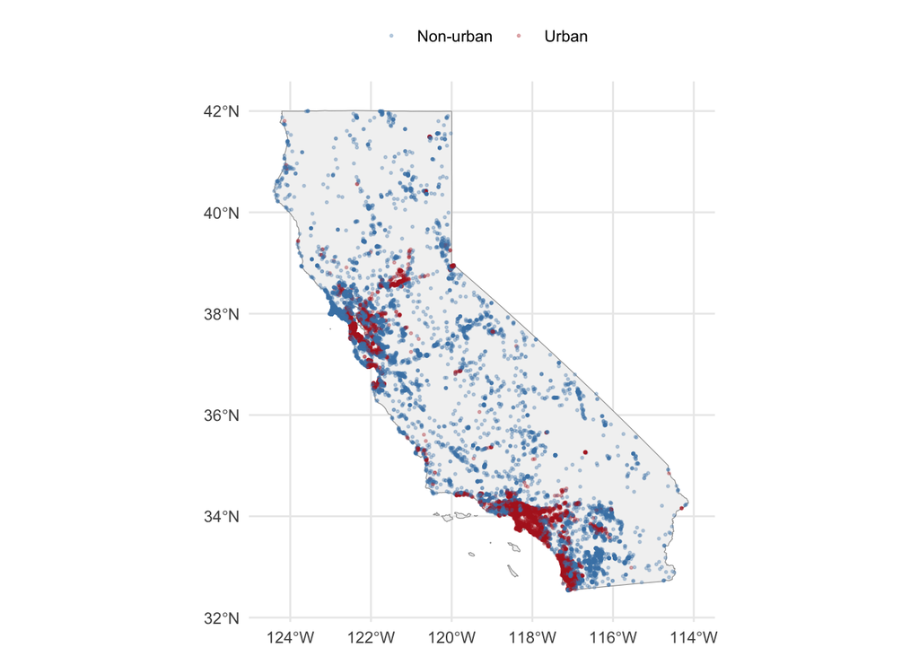

Figure 1: Coyote observations across California (1886–2026), colored by whether they fall within a Census-defined urban area. Each point is one observation.

Coyote observations span the entire state, from the Mojave to the north coast, confirming the thorough presence of the species across California. Urban observations (red) cluster sharply around the major metropolitan areas: greater Los Angeles, San Diego, the Bay Area, and Sacramento. Non-urban observations (blue) are scattered broadly across rural areas. The near-even split between the two categories is already visible.

## Observations over time

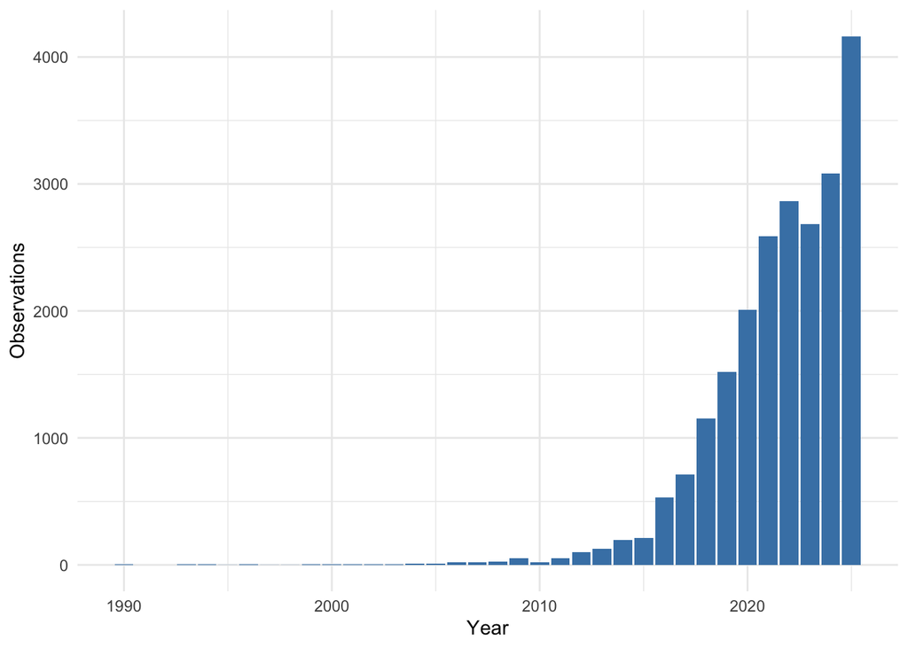

Figure 2: Coyote observations per year in California. The sharp rise after 2015 tracks the growth of citizen-science platforms rather than a sudden change in the coyote population.

## The urban share over time

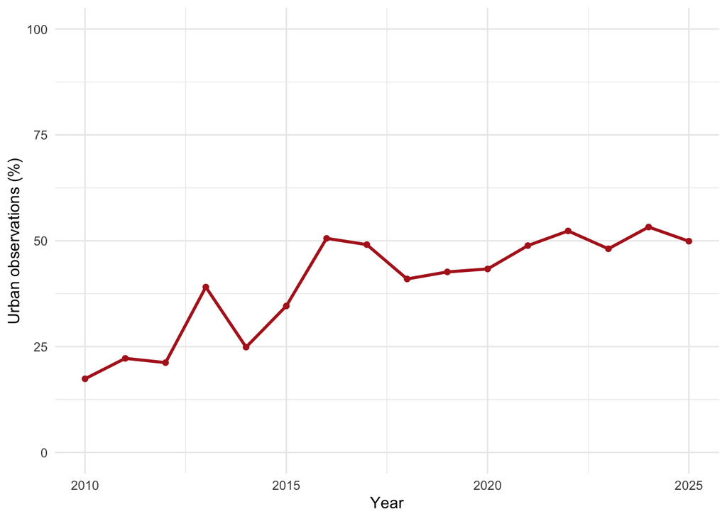

Figure 3: Percentage of coyote observations falling within urban areas, by year (2010–2025). The urban share roughly doubles over the period before leveling off near half.

The urban share of observations roughly doubled between 2010 and the early 2020s, climbing from under 20% to around 50%, where it has since leveled off. There are two competing explanations for this that the data cannot entirely separate. The first is that coyotes did in fact colonize California cities over this period. The second is that the rise also reflects who started using citizen-science apps. As platforms spread from naturalists in wild areas to ordinary city residents photographing backyard wildlife, the urban share of observations climbed regardless of any change in the coyotes themselves. The fact that this curve rises over exactly the same period as the overall observation explosion (Figure 2) suggests the second effect does much of the work. The honest conclusion is that both are likely happening, but occurrence data alone cannot reveal exactly how much of each.

## Seasonal patterns

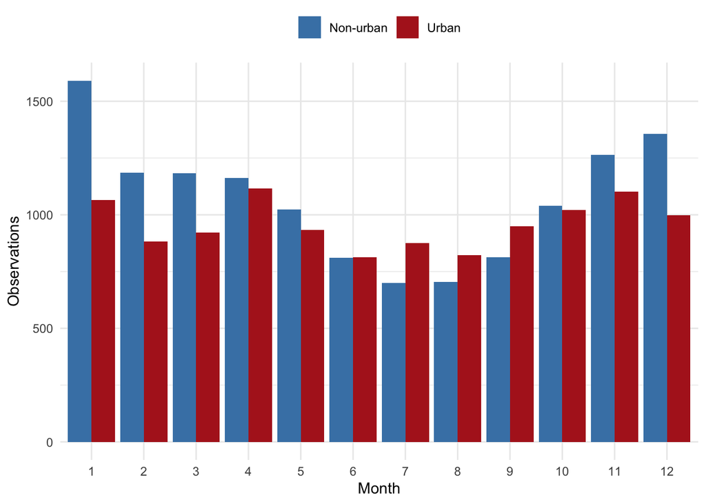

# Summary

Table 2: Coyote observations by decade, with the share falling in urban areas.

| Decade | Observations | Urban (%) |
| --- | --- | --- |
| 1950 | 22 | 13.6 |
| 1960 | 48 | 12.5 |
| 1970 | 83 | 13.3 |
| 1980 | 27 | 22.2 |
| 1990 | 19 | 15.8 |
| 2000 | 150 | 14.0 |
| 2010 | 4625 | 42.1 |
| 2020 | 18874 | 49.9 |

# Discussion

Three patterns stand out. Coyotes are observed across the entire state of California, in both dense cities and remote wildlands, with a near-even split. The volume of observations has also grown enormously since the mid-2010s. Lastly, the urban share of observations has roughly doubled over the same period before leveling off. The thread connecting all three is that occurrence data conflates two things: the distribution of coyotes and the distribution of observers. The explosive growth in records, as previously noted, is driven mostly by citizen-science adoption, not a population boom. The rising urban share likely reflects both real urban colonization and the spread of observation apps into cities. Even the seasonal patterns may mix coyote behavior with human activity. None of these can be cleanly separated using occurrence data alone. This is not a weakness unique to this dataset. Rather, it is the central challenge of working with circumstantially dependent biodiversity records. Used carefully, GBIF data is still valuable. It reliably shows that coyotes are present across California’s full range of environments, and it captures the dramatic recent growth in public engagement with urban wildlife. Unfortunately, it simply cannot quantify how much of an observed trend is animal and how much is observer.

## References

Chamberlain, Scott et al. 2025. *Rgbif: Interface to the Global Biodiversity Information Facility API*. https://CRAN.R-project.org/package=rgbif.

GBIF.org. 2026. *GBIF Occurrence Download*. https://doi.org/10.15468/dl.dxmt6t.

Gehrt, Stanley D., Chris Anchor, and Lynsey A. White. 2009. “Home Range and Landscape Use of Coyotes in a Metropolitan Landscape: Conflict or Coexistence?” *Journal of Mammalogy* 90 (5): 1045–57. https://doi.org/10.1644/08-MAMM-A-277.1.

Hody, James W., and Roland Kays. 2018. “Mapping the Expansion of Coyotes (Canis Latrans) Across North and Central America.” *ZooKeys* 759: 81–97. https://doi.org/10.3897/zookeys.759.15149.

Pebesma, Edzer. 2025. *Sf: Simple Features for r*. https://CRAN.R-project.org/package=sf.

R Core Team. 2025. *R: A Language and Environment for Statistical Computing*. R Foundation for Statistical Computing. https://www.R-project.org/.